# The likert Package

2016-12-15

## Likert Scales

Invented by Rensis Likert (1932).

Questionaire items where respondents respond to a question on a sequence of ordered responses. Common response types include:

- Agreement (e.g. Strongly Disagree, Disagree, Neither agree nor disagree, Agree, Strongly Agree)
- Frequency (e.g. Almost Never, Not Very Often, Somewhat Often, Pretty Often, Almost Often)
- Quality (e.g. Very Good, Good, Acceptable, Poor, Very Poor )
- Relevance (e.g. Excellent, Somewhat, Poor)
- Value (e.g. High, Moderate, Low, None)
- Importance (e.g. Very Important, Important, Moderately Important, Slightly Important, Not Important)

Likert, R (1932). [A technique for the measurement of attitudes](http://www.voteview.com/pdf/Likert_1932.pdf). *Archives of Psychology. 140*: 1–55.

## Categorical vs. Continuous

A key question to ask when using Likert items: Is the variable categorical or contiuous?

When considering the response to be continuous you are assuming the intervals are equal? That is:

\[ Strongly Agree - Agree = Disagree - Neutral \]

## Motivation

This package aims to provide the necessary tools to allow the user to make his/her own decisions about how the data should be treated, while also providing figures that may help clarify how well the assumptions discussed here hold up.

- summarize likert type items
- provide tabular results
- provide visualizations
- allow flexibility (e.g. ggplot2 annotate)
- have a consistent aesthetic
- use familiar S3 generics (i.e. print, plot, summary)

## Example: PISA Reading Attitudes

The Programme of International Student Assessment (PISA; 2009) assess ~15 year-old students about their reading attitudes:

- I read only if I have to.
- Reading is one of my favorite hobbies.
- I like talking about books with other people.
- I find it hard to finish books.
- I feel happy if I receive a book as a present.
- For me, reading is a waste of time.
- I enjoy going to a bookstore or a library.
- I read only to get information that I need.
- I cannot sit still and read for more than a few minutes.
- I like to express my opinions about books I have read.
- I like to exchange books with my friends.

Students respond to one of four options: Strongly disagree, Disagree, Agree, Strongly Agree

## Example: PISA Reading Attitudes

```r
library(likert)
```

Demo included in the package:

```r
demo('likert', package='likert')
```

Data preparation:

```r
data(pisaitems)
items24 <- pisaitems[,substr(names(pisaitems), 1,5) == 'ST24Q']
names(items24) <- c(ST24Q01 = "I read only if I have to.",
                    ST24Q02 = "Reading is one of my favorite hobbies.",
                    ST24Q03 = "I like talking about books with other people.",
                    ST24Q04 = "I find it hard to finish books.",
                    ST24Q05 = "I feel happy if I receive a book as a present.",
                    ST24Q06 = "For me, reading is a waste of time.",
                    ST24Q07 = "I enjoy going to a bookstore or a library.",
                    ST24Q08 = "I read only to get information that I need.",
                    ST24Q09 = "I cannot sit still and read for more than a few minutes.",
                    ST24Q10 = "I like to express my opinions about books I have read.",
                    ST24Q11 = "I like to exchange books with my friends.")
```

## Example: PISA Reading Attitudes

```r
str(items24)
```

```
## 'data.frame':    66690 obs. of  11 variables:
##  $ I read only if I have to.                               : Factor w/ 4 levels "Strongly disagree",..: 2 3 4 2 1 3 2 3 3 4 ...
##  $ Reading is one of my favorite hobbies.                  : Factor w/ 4 levels "Strongly disagree",..: 4 1 1 2 2 1 2 1 3 1 ...
##  $ I like talking about books with other people.           : Factor w/ 4 levels "Strongly disagree",..: 4 1 1 3 1 1 2 1 2 1 ...
##  $ I find it hard to finish books.                         : Factor w/ 4 levels "Strongly disagree",..: 1 4 3 1 2 3 4 3 3 3 ...
##  $ I feel happy if I receive a book as a present.          : Factor w/ 4 levels "Strongly disagree",..: 4 1 1 2 1 1 2 3 1 2 ...
##  $ For me, reading is a waste of time.                     : Factor w/ 4 levels "Strongly disagree",..: 1 3 4 2 2 3 2 2 3 4 ...
##  $ I enjoy going to a bookstore or a library.              : Factor w/ 4 levels "Strongly disagree",..: 3 1 1 3 2 1 2 1 2 1 ...
##  $ I read only to get information that I need.             : Factor w/ 4 levels "Strongly disagree",..: 2 3 3 1 3 3 4 2 3 4 ...
##  $ I cannot sit still and read for more than a few minutes.: Factor w/ 4 levels "Strongly disagree",..: 1 4 2 1 3 4 3 1 3 4 ...
##  $ I like to express my opinions about books I have read.  : Factor w/ 4 levels "Strongly disagree",..: 3 1 2 3 3 1 3 2 3 3 ...
##  $ I like to exchange books with my friends.               : Factor w/ 4 levels "Strongly disagree",..: 3 1 1 3 1 1 2 3 3 1 ...
```

## Using the `likert` function

```r
l24 <- likert(items24)
l24 #print(l24)
```

```
##                                                        Item Strongly disagree Disagree Agree Strongly agree
## 1                                 I read only if I have to.              22.8     35.9  30.5          10.73
## 2                    Reading is one of my favorite hobbies.              20.3     36.3  31.9          11.42
## 3             I like talking about books with other people.              21.2     33.7  36.0           9.05
## 4                           I find it hard to finish books.              25.0     40.4  26.5           8.14
## 5            I feel happy if I receive a book as a present.              19.3     27.7  40.2          12.89
## 6                       For me, reading is a waste of time.              42.2     40.6  11.0           6.14
## 7                I enjoy going to a bookstore or a library.              17.8     33.4  36.9          11.90
## 8               I read only to get information that I need.              15.0     35.4  35.8          13.84
## 9  I cannot sit still and read for more than a few minutes.              33.1     43.1  16.9           6.84
## 10   I like to express my opinions about books I have read.              13.5     27.5  43.8          15.10
## 11                I like to exchange books with my friends.              22.5     33.0  32.1          12.38
```

## Numeric Results

```r
summary(l24)
```

```
##                                                        Item  low neutral high mean    sd
## 10   I like to express my opinions about books I have read. 41.1       0 58.9 2.60 0.901
## 5            I feel happy if I receive a book as a present. 46.9       0 53.1 2.47 0.945
## 8               I read only to get information that I need. 50.4       0 49.6 2.48 0.909
## 7                I enjoy going to a bookstore or a library. 51.2       0 48.8 2.43 0.916
## 3             I like talking about books with other people. 55.0       0 45.0 2.33 0.909
## 11                I like to exchange books with my friends. 55.5       0 44.5 2.34 0.961
## 2                    Reading is one of my favorite hobbies. 56.6       0 43.4 2.34 0.928
## 1                                 I read only if I have to. 58.7       0 41.3 2.29 0.937
## 4                           I find it hard to finish books. 65.4       0 34.6 2.18 0.899
## 9  I cannot sit still and read for more than a few minutes. 76.2       0 23.8 1.97 0.879
## 6                       For me, reading is a waste of time. 82.9       0 17.1 1.81 0.861
```

## Plotting Likert Results

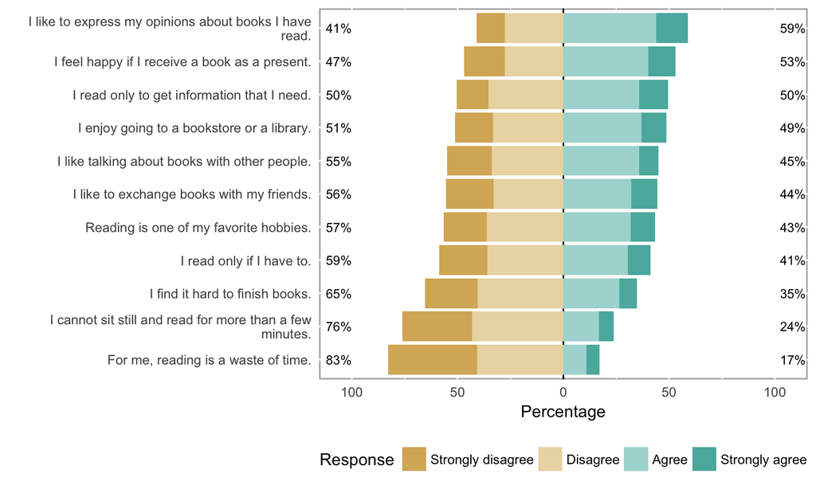

```r
plot(l24)
```

## Plotting Likert Results (center)

The `center` option will define what category is considered to be the center.

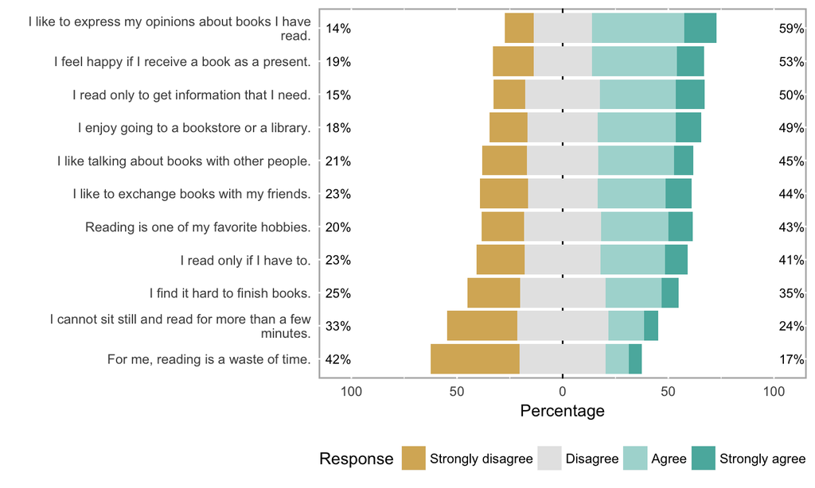

```r
plot(l24, center=2)
```

## Plotting Likert Results (ordering)

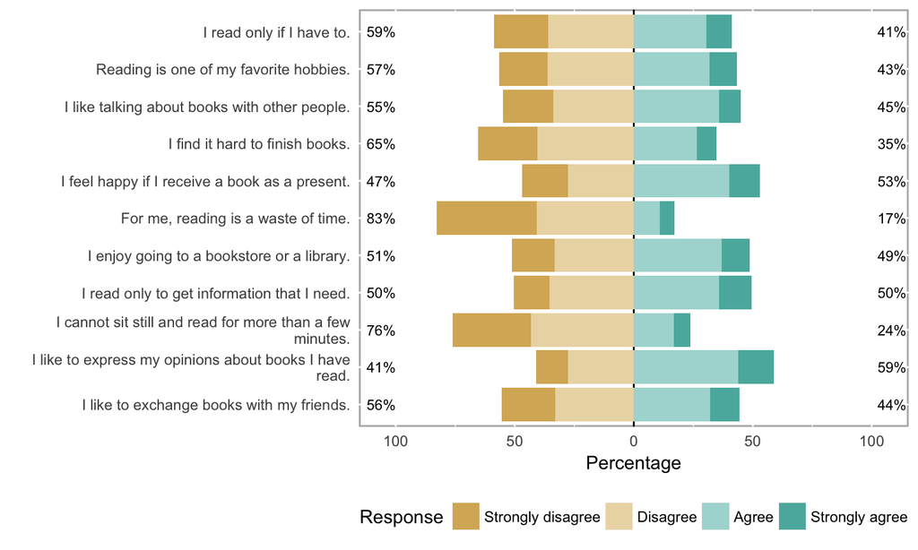

```r
plot(l24, ordered=FALSE, group.order=names(items24)) #Specify the exact order of the y-axis
```

## Plotting Likert Results (changing colors)

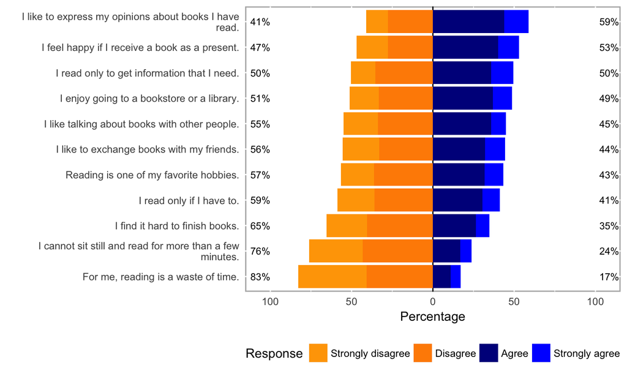

```r
plot(l24, colors=c('orange','darkorange','darkblue','blue'))
```

## Plotting Likert Results (response histograms)

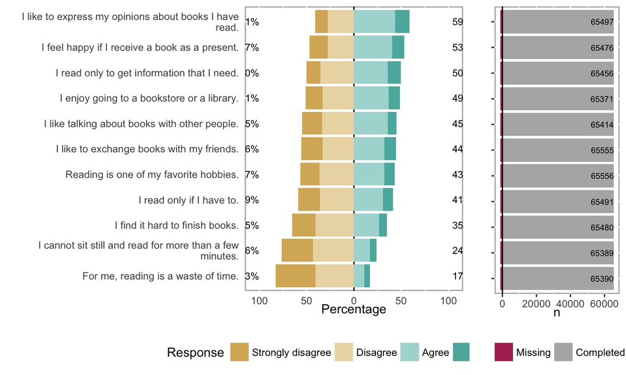

```r
plot(l24, include.histogram=TRUE)
```

## Density Plots

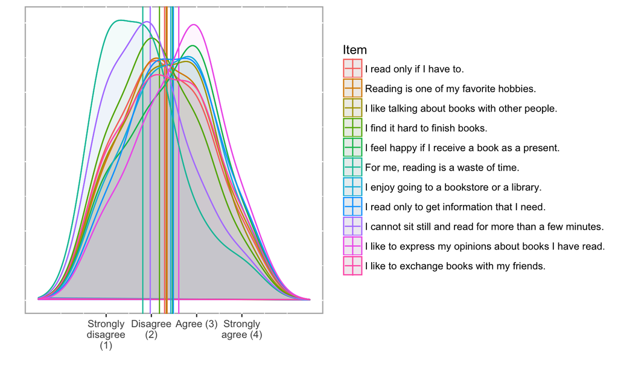

```r
plot(l24, type='density', facet=FALSE)
```

## Heatmap Plots

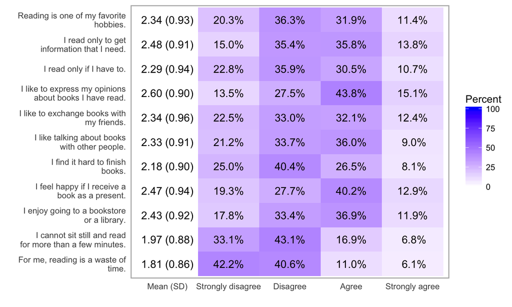

```r
plot(l24, type='heat', wrap=30, text.size=4)
```

## Grouping Responses

```r
l24g <- likert(items24[,1:5], grouping=pisaitems$CNT)
print(l24g)
```

```
##            Group                                           Item Strongly disagree Disagree Agree Strongly agree
## 1         Canada                      I read only if I have to.              25.7     35.1  24.9          14.29
## 2         Canada         Reading is one of my favorite hobbies.              26.8     35.2  24.6          13.40
## 3         Canada  I like talking about books with other people.              25.2     31.7  33.5           9.62
## 4         Canada                I find it hard to finish books.              31.3     40.4  19.7           8.53
## 5         Canada I feel happy if I receive a book as a present.              23.5     26.7  37.8          12.03
## 6         Mexico                      I read only if I have to.              21.9     36.8  33.5           7.90
## 7         Mexico         Reading is one of my favorite hobbies.              15.3     36.4  37.8          10.52
## 8         Mexico  I like talking about books with other people.              18.4     34.8  37.9           8.88
## 9         Mexico                I find it hard to finish books.              21.1     39.9  31.1           7.91
## 10        Mexico I feel happy if I receive a book as a present.              15.5     27.5  42.9          14.18
## 11 United States                      I read only if I have to.              17.2     33.0  34.0          15.85
## 12 United States         Reading is one of my favorite hobbies.              29.1     40.5  21.0           9.37
## 13 United States  I like talking about books with other people.              24.3     35.1  32.8           7.76
## 14 United States                I find it hard to finish books.              25.3     43.6  23.0           8.10
## 15 United States I feel happy if I receive a book as a present.              28.7     33.4  30.7           7.25
```

## Grouping Responses: Summary

```r
summary(l24g)
```

```
##            Group                                           Item  low neutral high mean    sd
## 1         Canada                      I read only if I have to. 60.8       0 39.2 2.28 1.000
## 2         Canada         Reading is one of my favorite hobbies. 62.0       0 38.0 2.25 0.995
## 3         Canada  I like talking about books with other people. 56.9       0 43.1 2.27 0.947
## 4         Canada                I find it hard to finish books. 71.8       0 28.2 2.05 0.921
## 5         Canada I feel happy if I receive a book as a present. 50.1       0 49.9 2.38 0.973
## 6         Mexico                      I read only if I have to. 58.6       0 41.4 2.27 0.891
## 7         Mexico         Reading is one of my favorite hobbies. 51.7       0 48.3 2.44 0.873
## 8         Mexico  I like talking about books with other people. 53.2       0 46.8 2.37 0.883
## 9         Mexico                I find it hard to finish books. 61.0       0 39.0 2.26 0.878
## 10        Mexico I feel happy if I receive a book as a present. 43.0       0 57.0 2.56 0.917
## 11 United States                      I read only if I have to. 50.2       0 49.8 2.49 0.954
## 12 United States         Reading is one of my favorite hobbies. 69.6       0 30.4 2.11 0.930
## 13 United States  I like talking about books with other people. 59.5       0 40.5 2.24 0.908
## 14 United States                I find it hard to finish books. 68.9       0 31.1 2.14 0.888
## 15 United States I feel happy if I receive a book as a present. 62.0       0 38.0 2.17 0.926
```

## Grouping Responses: Plotting

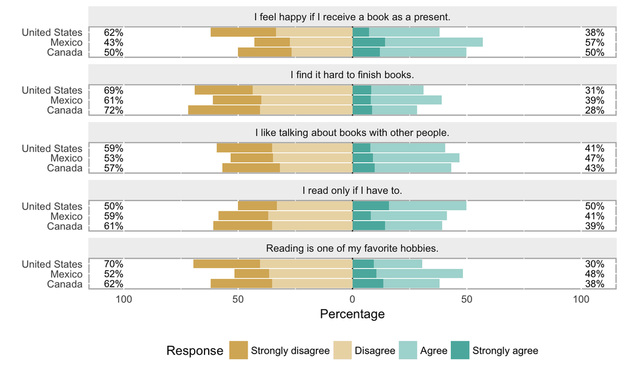

```r
plot(l24g)
```

## Example 2: DAACS Pre-Pilot

**daacs.net/shiny/PrePilot**